# BABI_AUG18_Batch_Thyroid_analysis

Read the data file

```python
import numpy             as np
import pandas            as  pd
import seaborn           as  sns
import matplotlib.pyplot as  plt
import sys, os

# from   common           import  draw_boxplot, draw_hist, split_target_predictor, split_train_test

print("\nCurrent working directory %s" %os.getcwd())
```

```
Current working directory D:\RRD\Courseware\ipynb files
```

```python
data = pd.read_csv('D:/GL/Capstone/Chennai/Aug18/data/hypothyroid.csv')
n    =  data.shape[0]
```

```python
print(data.shape)
```

```
(3772, 30)
```

### Observations

There are 3772 observations and 30 columns for our dataset.

```python
print(data.info())
```

```
<class 'pandas.core.frame.DataFrame'>
RangeIndex: 3772 entries, 0 to 3771
Data columns (total 30 columns):
age                          3772 non-null object
sex                          3772 non-null object
on thyroxine                 3772 non-null object
query on thyroxine           3772 non-null object
on antithyroid medication    3772 non-null object
sick                         3772 non-null object
pregnant                     3772 non-null object
thyroid surgery              3772 non-null object
I131 treatment               3772 non-null object
query hypothyroid            3772 non-null object
query hyperthyroid           3772 non-null object
lithium                      3772 non-null object
goitre                       3772 non-null object
tumor                        3772 non-null object
hypopituitary                3772 non-null object
psych                        3772 non-null object
TSH measured                 3772 non-null object
TSH                          3772 non-null object
T3 measured                  3772 non-null object
T3                           3772 non-null object
TT4 measured                 3772 non-null object
TT4                          3772 non-null object
T4U measured                 3772 non-null object
T4U                          3772 non-null object
FTI measured                 3772 non-null object
FTI                          3772 non-null object
TBG measured                 3772 non-null object
TBG                          3772 non-null object
referral source              3772 non-null object
binaryClass                  3772 non-null object
dtypes: object(30)
memory usage: 884.1+ KB
None
```

```python
print(data.head(4).T)
```

```
                              0      1      2      3
age                          41     23     46     70
sex                           F      F      M      F
on thyroxine                  f      f      f      t
query on thyroxine            f      f      f      f
on antithyroid medication     f      f      f      f
sick                          f      f      f      f
pregnant                      f      f      f      f
thyroid surgery               f      f      f      f
I131 treatment                f      f      f      f
query hypothyroid             f      f      f      f
query hyperthyroid            f      f      f      f
lithium                       f      f      f      f
goitre                        f      f      f      f
tumor                         f      f      f      f
hypopituitary                 f      f      f      f
psych                         f      f      f      f
TSH measured                  t      t      t      t
TSH                         1.3    4.1   0.98   0.16
T3 measured                   t      t      f      t
T3                          2.5      2      ?    1.9
TT4 measured                  t      t      t      t
TT4                         125    102    109    175
T4U measured                  t      f      t      f
T4U                        1.14      ?   0.91      ?
FTI measured                  t      f      t      f
FTI                         109      ?    120      ?
TBG measured                  f      f      f      f
TBG                           ?      ?      ?      ?
referral source            SVHC  other  other  other
binaryClass                   P      P      P      P
```

There are missing values denoted by ?. We need to replace them with null.

```python
df = data.replace('?', np.NaN)
print(df.head(4).T)
```

```
                              0      1      2      3
age                          41     23     46     70
sex                           F      F      M      F
on thyroxine                  f      f      f      t
query on thyroxine            f      f      f      f
on antithyroid medication     f      f      f      f
sick                          f      f      f      f
pregnant                      f      f      f      f
thyroid surgery               f      f      f      f
I131 treatment                f      f      f      f
query hypothyroid             f      f      f      f
query hyperthyroid            f      f      f      f
lithium                       f      f      f      f
goitre                        f      f      f      f
tumor                         f      f      f      f
hypopituitary                 f      f      f      f
psych                         f      f      f      f
TSH measured                  t      t      t      t
TSH                         1.3    4.1   0.98   0.16
T3 measured                   t      t      f      t
T3                          2.5      2    NaN    1.9
TT4 measured                  t      t      t      t
TT4                         125    102    109    175
T4U measured                  t      f      t      f
T4U                        1.14    NaN   0.91    NaN
FTI measured                  t      f      t      f
FTI                         109    NaN    120    NaN
TBG measured                  f      f      f      f
TBG                         NaN    NaN    NaN    NaN
referral source            SVHC  other  other  other
binaryClass                   P      P      P      P
```

```python
all_columns         = list(df)
numeric_columns     = ['age', 'TSH', 'T3', 'TT4', 'T4U', 'FTI']
categorical_columns = [x for x in all_columns if x not in numeric_columns ]

print('\nNumeric columns')
print(numeric_columns)
print('\nCategorical columns')
print(categorical_columns)
```

```
Numeric columns
['age', 'TSH', 'T3', 'TT4', 'T4U', 'FTI']

Categorical columns
['sex', 'on thyroxine', 'query on thyroxine', 'on antithyroid medication', 'sick', 'pregnant', 'thyroid surgery', 'I131 treatment', 'query hypothyroid', 'query hyperthyroid', 'lithium', 'goitre', 'tumor', 'hypopituitary', 'psych', 'TSH measured', 'T3 measured', 'TT4 measured', 'T4U measured', 'FTI m…
```

```python
print(df.info())
```

```
<class 'pandas.core.frame.DataFrame'>
RangeIndex: 3772 entries, 0 to 3771
Data columns (total 30 columns):
age                          3771 non-null object
sex                          3622 non-null object
on thyroxine                 3772 non-null object
query on thyroxine           3772 non-null object
on antithyroid medication    3772 non-null object
sick                         3772 non-null object
pregnant                     3772 non-null object
thyroid surgery              3772 non-null object
I131 treatment               3772 non-null object
query hypothyroid            3772 non-null object
query hyperthyroid           3772 non-null object
lithium                      3772 non-null object
goitre                       3772 non-null object
tumor                        3772 non-null object
hypopituitary                3772 non-null object
psych                        3772 non-null object
TSH measured                 3772 non-null object
TSH                          3403 non-null object
T3 measured                  3772 non-null object
T3                           3003 non-null object
TT4 measured                 3772 non-null object
TT4                          3541 non-null object
T4U measured                 3772 non-null object
T4U                          3385 non-null object
FTI measured                 3772 non-null object
FTI                          3387 non-null object
TBG measured                 3772 non-null object
TBG                          0 non-null float64
referral source              3772 non-null object
binaryClass                  3772 non-null object
dtypes: float64(1), object(29)
memory usage: 884.1+ KB
None
```

Get column-wise count of missing values along with %.

```python
df.isnull().apply(lambda x : [ sum(x), (sum(x) * 100) / df.shape[0]] )
```

```
age                          [1, 0.026511134676564158]
sex                          [150, 3.9766702014846236]
on thyroxine                                  [0, 0.0]
query on thyroxine                            [0, 0.0]
on antithyroid medication                     [0, 0.0]
sick                                          [0, 0.0]
pregnant                                      [0, 0.0]
thyroid surgery                               [0, 0.0]
I131 treatment                                [0, 0.0]
query hypothyroid                             [0, 0.0]
query hyperthyroid                            [0, 0.0]
lithium                                       [0, 0.0]
goitre                                        [0, 0.0]
tumor                                         [0, 0.0]
hypopituitary                                 [0, 0.0]
psych                                         [0, 0.0]
TSH measured                                  [0, 0.0]
TSH                           [369, 9.782608695652174]
T3 measured                                   [0, 0.0]
T3                           [769, 20.387062566277837]
TT4 measured                                  [0, 0.0]
TT4                          [231, 6.1240721102863205]
T4U measured                                  [0, 0.0]
T4U                           [387, 10.25980911983033]
FTI measured                                  [0, 0.0]
FTI                            [385, 10.2067868504772]
TBG measured                                  [0, 0.0]
TBG                                      [3772, 100.0]
referral source                               [0, 0.0]
binaryClass                                   [0, 0.0]
dtype: object
```

### Observation

| # | Column | [ count, %] |
| --- | --- | --- |
| 1 | age | [1, 0.026511134676564158] |
| 2 | sex | [150, 3.9766702014846236] |
| 3 | TSH | [369, 9.782608695652174] |
| 4 | T3 | [769, 20.387062566277837] |
| 5 | TT4 | [231, 6.1240721102863205] |
| 6 | T4U | [387, 10.25980911983033] |
| 7 | FTI | [385, 10.2067868504772] |
| 8 | TBG | [3772, 100.0] |

### Observations

Except the column, TBG, all other seven columns have percentage of missing values less than 30 %. The column, TBG is having 100% missing values. We shall drop the column, TBG and remove the missing values row-wise.

```python
df.drop(columns = 'TBG', axis = 0, inplace = True)
df.dropna(axis = 0, inplace = True)
```

The following variables are numeric and float and need to converted from object class.

```python
df['age'] = df['age'].astype('int32')
df['TSH'] = df['TSH'].astype('float64')
df['T3']  = df['T3'].astype('float64')
df['TT4'] = df['TT4'].astype('float64')
df['T4U'] = df['T4U'].astype('float64')
df['FTI'] = df['FTI'].astype('float64')
```

```python
categorical_columns = ['sex', 'on thyroxine', 'query on thyroxine', 'on antithyroid medication', 'sick', \
                        'pregnant', 'thyroid surgery', 'I131 treatment', 'query hypothyroid', 'query hyperthyroid', \
                        'lithium', 'goitre', 'tumor', 'hypopituitary', 'psych', 'TSH measured',\
                        'T3 measured', 'TT4 measured', 'T4U measured', 'FTI measured', 'TBG measured',\
                        'referral source', 'binaryClass']
for name1 in categorical_columns:
    print("\nColumn: ", name1,"\n")
    print(df[name1].value_counts())
```

```
Column:  sex

F    1764
M     879
Name: sex, dtype: int64

Column:  on thyroxine

f    2377
t     266
Name: on thyroxine, dtype: int64

Column:  query on thyroxine

f    2619
t      24
Name: query on thyroxine, dtype: int64

Column:  on antithyroid medication

f    2610
t      33
Name: on antithyroid medication, dtype: int64

Column:  sick

f    2530
t     113
Name: sick, dtype: int64

Column:  pregnant

f    2602
t      41
Name: pregnant, dtype: int64

Column:  thyroid surgery

f    2610
t      33
```

[output cut: 79 more lines]

```

Column:  referral source

other    1237
SVI       929
SVHC      359
STMW       84
SVHD       34
Name: referral source, dtype: int64

Column:  binaryClass

P    2427
N     216
Name: binaryClass, dtype: int64
```

So, we remove all these columns

```python
unwanted_columns    = ['TSH measured','T3 measured','TT4 measured','T4U measured','FTI measured','TBG measured','hypopituitary']
df.drop(columns     = unwanted_columns, inplace = True )
categorical_columns = ['sex', 'on thyroxine', 'query on thyroxine', 'on antithyroid medication', 'sick', \
                        'pregnant', 'thyroid surgery', 'I131 treatment', 'query hypothyroid', 'query hyperthyroid', \
                        'lithium', 'goitre', 'tumor', 'psych', 'referral source', 'binaryClass']
```

```python
print(df.shape)
```

```
(2643, 22)
```

### Observations

We have started with 3772 observations and 30 columns.

- There are ? values for some observations in seven fields and all observations in the field, TBG.
- These ? value is replaced as null value.
- Since 100% of observations have null value in the field, TBG, we need to remove the field for our analysis.
- For other fields, missing values range from 0.02 to 20.38%. We decided to drop missing values row-wise since we do not want to introduce bias into the data.
- Now, we have 2643 not null observations out of 3772 total observations.
- We have removed TBG column full of null values from the dataframe.
- We have removed columns such as 'TSH measured','T3 measured','TT4 measured','T4U measured','FTI measured','TBG measured' and 'hypopituitary' with constant or near constant values.
- We have retained only 22 columns instead of 30 columns.

### Data is not balanced since the class distribution in the target variable is in the ratio 216: 2427

### Outlier detection

```python
print(df.describe())
print(df.describe(exclude = [np.number]))
```

```
               age          TSH           T3          TT4          T4U  \
count  2643.000000  2643.000000  2643.000000  2643.000000  2643.000000
mean     53.081725     5.035978     2.001150   107.858683     0.995650
std      20.367966    23.974851     0.823814    35.460437     0.196445
min       1.000000     0.005000     0.050000     2.000000     0.250000
25%      37.000000     0.500000     1.500000    88.000000     0.870000
50%      55.000000     1.300000     2.000000   103.000000     0.980000
75%      69.000000     2.600000     2.300000   124.000000     1.090000
max     455.000000   530.000000    10.600000   430.000000     2.120000

               FTI
count  2643.000000
mean    109.435906
std      32.472156
min       2.000000
25%      93.000000
50%     107.000000
75%     124.000000
max     395.000000
         sex on thyroxine query on thyroxine on antithyroid medication  sick  \
count   2643         2643               2643                      2643  2643
unique     2            2                  2                         2     2
top        F            f                  f                         f     f
freq    1764         2377               2619                      2610  2530

       pregnant thyroid surgery I131 treatment query hypothyroid  \
count      2643            2643           2643              2643
unique        2               2              2                 2
top           f               f              f                 f
freq       2602            2610           2603              2497

       query hyperthyroid lithium goitre tumor psych referral source  \
count                2643    2643   2643  2643  2643            2643
unique                  2       2      2     2     2               5
top                     f       f      f     f     f           other
freq                 2480    2629   2623  2585  2473            1237

       binaryClass
count         2643
unique           2
top              P
freq          2427
```

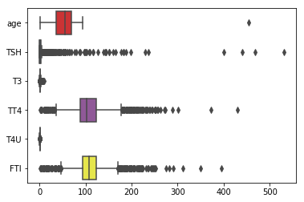

```python
ax = sns.boxplot(data = df, orient = "h", palette = "Set1")
plt.show()
```

```python
def outlier_detect(df):
    for i in df.describe().columns:

        Q1=df.describe().at['25%',i]
        Q3=df.describe().at['75%',i]
        IQR=Q3 - Q1
        LTV=Q1 - 1.5 * IQR
        UTV=Q3 + 1.5 * IQR
        x=np.array(df[i])
        p=[]
        for j in x:
            if j < LTV or j>UTV:
               p.append(j)
        print('\n Outliers for Column : ', i, ' Outliers count ', len(p))
        print(p)
```

```python
x           =  df[numeric_columns]
outlier_detect(x)
```

```
 Outliers for Column :  age  Outliers count  1
[455]

 Outliers for Column :  TSH  Outliers count  278
[6.0, 13.0, 7.3, 45.0, 14.8, 15.0, 19.0, 160.0, 12.0, 151.0, 7.8, 13.0, 6.0, 26.0, 143.0, 108.0, 9.2, 86.0, 9.1, 52.0, 6.1, 31.0, 51.0, 6.3, 9.6, 42.0, 12.0, 25.0, 8.6, 6.2, 9.7, 28.0, 17.0, 18.0, 55.0, 14.0, 16.0, 10.0, 6.7, 7.6, 8.0, 11.0, 11.0, 44.0, 7.9, 11.0, 15.0, 7.2, 12.0, 6.4, 7.1, 199.0, 1…

 Outliers for Column :  T3  Outliers count  153
[3.8, 0.3, 5.5, 0.3, 3.5, 5.5, 4.2, 0.3, 3.7, 3.7, 4.3, 0.05, 5.4, 0.3, 4.0, 3.8, 4.8, 0.2, 0.2, 0.2, 0.3, 5.2, 3.6, 0.2, 3.5, 6.0, 3.6, 3.5, 5.0, 5.3, 4.2, 3.9, 4.0, 3.7, 3.8, 4.6, 4.5, 7.3, 4.7, 6.7, 0.3, 4.1, 3.9, 3.8, 3.5, 3.7, 4.0, 0.2, 0.05, 3.7, 3.7, 3.8, 3.8, 4.3, 3.9, 3.5, 4.5, 0.3, 0.1, 0.…

 Outliers for Column :  TT4  Outliers count  151
[199.0, 11.0, 32.0, 217.0, 32.0, 205.0, 225.0, 219.0, 189.0, 184.0, 14.0, 189.0, 27.0, 193.0, 13.0, 12.0, 257.0, 18.0, 183.0, 33.0, 183.0, 203.0, 183.0, 250.0, 181.0, 223.0, 272.0, 235.0, 10.0, 231.0, 191.0, 5.8, 210.0, 181.0, 232.0, 204.0, 430.0, 198.0, 230.0, 13.0, 15.0, 194.0, 181.0, 179.0, 205.0…

 Outliers for Column :  T4U  Outliers count  108
[1.55, 0.53, 1.44, 1.51, 1.51, 1.68, 1.46, 1.66, 1.51, 0.52, 1.83, 1.5, 1.93, 1.82, 1.67, 1.43, 1.77, 1.59, 1.69, 1.74, 2.03, 1.43, 1.68, 1.73, 1.52, 1.63, 1.65, 1.53, 1.74, 1.58, 1.84, 1.67, 1.57, 1.5, 1.75, 1.46, 1.65, 1.55, 1.57, 1.79, 1.65, 1.8, 0.48, 1.71, 1.62, 1.52, 1.76, 1.73, 1.56, 1.77, 1.…

 Outliers for Column :  FTI  Outliers count  161
[190.0, 33.0, 171.0, 186.0, 180.0, 8.9, 41.0, 221.0, 28.0, 274.0, 14.0, 32.0, 11.0, 10.0, 214.0, 200.0, 16.0, 43.0, 179.0, 224.0, 220.0, 182.0, 312.0, 281.0, 207.0, 214.0, 10.0, 251.0, 194.0, 46.0, 7.0, 190.0, 216.0, 174.0, 41.0, 395.0, 185.0, 13.0, 14.0, 171.0, 173.0, 171.0, 188.0, 235.0, 186.0, 17…
```

```python
"""

 1) Function: draw_barplot()

   Description: Description: This program does the following:
                i)  prints the cross tab with count and row percentages
                ii) plots grouped bar chart (grouped by the target variable, AHD
   Input:
       1) Data Frame

       2) Column name of the predictor variable selected

       3) Label for the predictor variable

       4) Title for the grouped bar chart

   Output:
       1) Cross tab with count and row percentages

      2)  Grouped Bar chart

"""

def draw_barplot(df, X, xlab, title, Y):

    x       =   df[X]
    y       =   df[Y]
    ct = pd.crosstab(df[X], y)
    print("\n Cross tab with count\n")
    print(ct)

    ### Cross tab with row percentages
    print("\n Cross tab with row % \n")
    ct1 = pd.crosstab(df[X], Y, normalize = 'index').round(4)*100
    print(ct1)

    # now stack and reset
    stacked = ct.stack().reset_index().rename(columns={0:'value'})
    print(list(stacked))
    ##plot grouped bar chart
    ax = sns.barplot(x = stacked[X], y = stacked.value, hue = stacked[Y])
    ax.set_title(title)
    plt.show()

### -----------------------------------------------------------------------------------------------------------------------------

"""

2)  Function name: draw_boxplot()

    Description: This program does the following:
                 i) prints the summary statistics grouped by target variable
                ii) plots box chart (grouped by the target variable

    Input:
          1) Data Frame containing the data for analysis

          2) Column name of the predictor variable selected

          3) Label for the predictor variable

          4) Title for the grouped bar chart

    Output:
          1) Cross tab with count and row percentages

          2) Grouped Bar chart

"""
def draw_boxplot(df, X, xlab, title, Y):
    import seaborn           as sns
    import matplotlib.pyplot as plt

    x       =   df[X]
    print("\n Summary statistics for  " + xlab + "\n")
    print(df[X].groupby(df[Y]).describe().T)

    sns.set_style("whitegrid")
    ax = sns.boxplot(x = df[X] ,y =  df[Y])
    ax.set_title(title)
    plt.show()

### -----------------------------------------------------------------------------------------------------------------------------
"""

3)  Function name: draw_hist

    Description: This function plots a histogram for the specified variable

    Input:
        1) Data Frame containing numerical variable

    Output:
        1) A **histogram** graph

"""

def draw_hist(df, X, title):
    import seaborn           as sns
    import matplotlib.pyplot as plt

    sns.distplot(df[X]).set_title(title);
    plt.show();

### -----------------------------------------------------------------------------------------------------------------------------
```

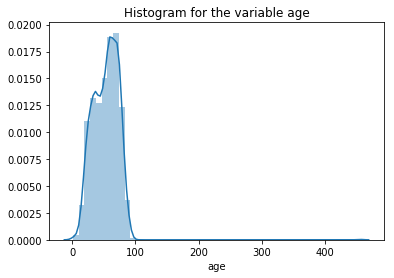

```
 Summary statistics for  age

binaryClass           N            P
count        216.000000  2427.000000
mean          53.125000    53.077874
std           16.788926    20.659393
min            7.000000     1.000000
25%           40.000000    37.000000
50%           55.000000    55.000000
75%           65.500000    69.000000
max           85.000000   455.000000
```

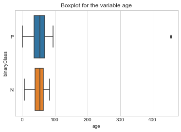

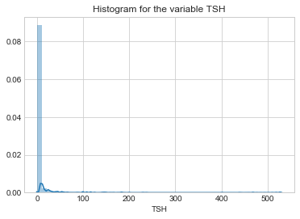

```
 Summary statistics for  TSH

binaryClass           N            P
count        216.000000  2427.000000
mean          41.174074     1.819732
std           73.313813     4.796108
min            4.600000     0.005000
25%            8.300000     0.400000
50%           13.000000     1.200000
75%           38.500000     2.200000
max          530.000000   145.000000
```

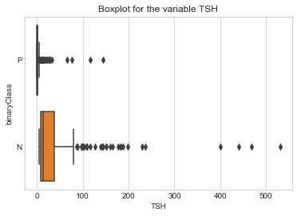

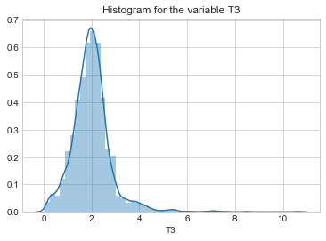

```
 Summary statistics for  T3

binaryClass           N            P
count        216.000000  2427.000000
mean           1.463426     2.049007
std            0.764750     0.811929
min            0.200000     0.050000
25%            0.800000     1.600000
50%            1.500000     2.000000
75%            2.025000     2.400000
max            4.100000    10.600000
```

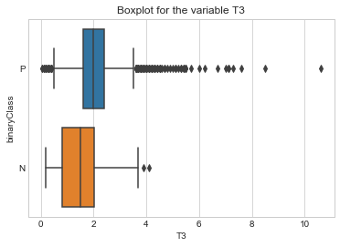

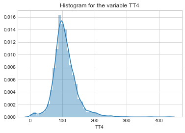

```
 Summary statistics for  TT4

binaryClass           N            P
count        216.000000  2427.000000
mean          70.090278   111.220025
std           35.314094    33.474926
min            2.000000    19.000000
25%           45.000000    90.000000
50%           72.500000   105.000000
75%           92.500000   126.000000
max          146.000000   430.000000
```

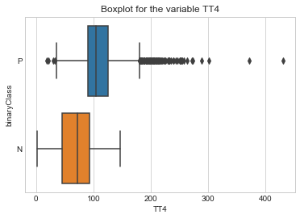

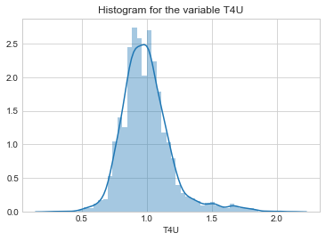

```
 Summary statistics for  T4U

binaryClass           N            P
count        216.000000  2427.000000
mean           1.010556     0.994324
std            0.187524     0.197202
min            0.560000     0.250000
25%            0.880000     0.870000
50%            1.010000     0.970000
75%            1.112500     1.080000
max            1.650000     2.120000
```

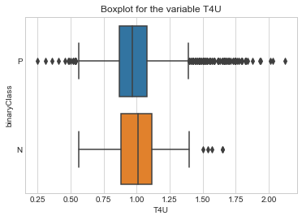

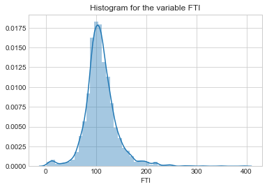

```
 Summary statistics for  FTI

binaryClass           N            P
count        216.000000  2427.000000
mean          70.486574   112.902349
std           34.071791    29.972479
min            2.000000    17.000000
25%           49.000000    95.000000
50%           74.500000   108.000000
75%           97.000000   125.000000
max          153.000000   395.000000
```

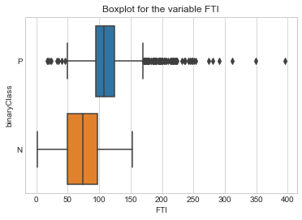

```python
for i in range(len(numeric_columns)):
    feature_X  = numeric_columns[i]
    target_Y   = 'binaryClass'
    title      = "Histogram for the variable " + feature_X
    draw_hist(df, feature_X, title)
    title      = "Boxplot for the variable " + feature_X
##
    draw_boxplot(df, feature_X, feature_X, title, target_Y)
```

```
 Cross tab with count

binaryClass    N     P
sex
F            167  1597
M             49   830

 Cross tab with row %

col_0  binaryClass
sex
F            100.0
M            100.0
['sex', 'binaryClass', 'value']
```

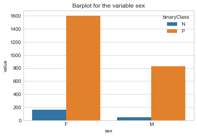

```
 Cross tab with count

binaryClass     N     P
on thyroxine
f             209  2168
t               7   259

 Cross tab with row %

col_0         binaryClass
on thyroxine
f                   100.0
t                   100.0
['on thyroxine', 'binaryClass', 'value']
```

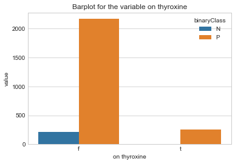

```
 Cross tab with count

binaryClass           N     P
query on thyroxine
f                   214  2405
t                     2    22

 Cross tab with row %

col_0               binaryClass
query on thyroxine
f                         100.0
t                         100.0
['query on thyroxine', 'binaryClass', 'value']
```

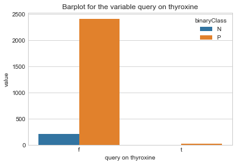

```
 Cross tab with count

binaryClass                  N     P
on antithyroid medication
f                          215  2395
t                            1    32

 Cross tab with row %

col_0                      binaryClass
on antithyroid medication
f                                100.0
t                                100.0
['on antithyroid medication', 'binaryClass', 'value']
```

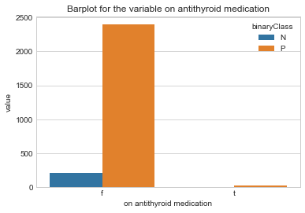

```
 Cross tab with count

binaryClass    N     P
sick
f            207  2323
t              9   104

 Cross tab with row %

col_0  binaryClass
sick
f            100.0
t            100.0
['sick', 'binaryClass', 'value']
```

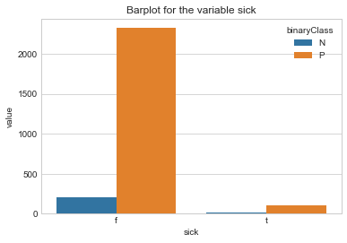

```
 Cross tab with count

binaryClass    N     P
pregnant
f            216  2386
t              0    41

 Cross tab with row %

col_0     binaryClass
pregnant
f               100.0
t               100.0
['pregnant', 'binaryClass', 'value']
```

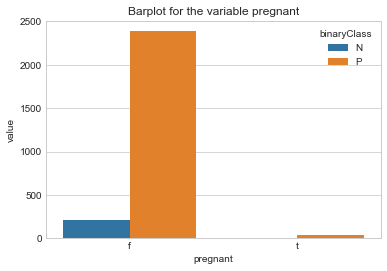

```
 Cross tab with count

binaryClass        N     P
thyroid surgery
f                215  2395
t                  1    32

 Cross tab with row %

col_0            binaryClass
thyroid surgery
f                      100.0
t                      100.0
['thyroid surgery', 'binaryClass', 'value']
```

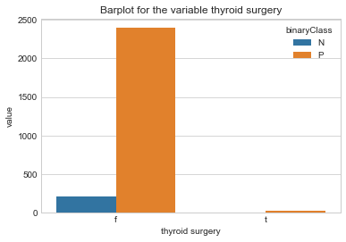

```
 Cross tab with count

binaryClass       N     P
I131 treatment
f               215  2388
t                 1    39

 Cross tab with row %

col_0           binaryClass
I131 treatment
f                     100.0
t                     100.0
['I131 treatment', 'binaryClass', 'value']
```

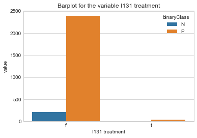

```
 Cross tab with count

binaryClass          N     P
query hypothyroid
f                  191  2306
t                   25   121

 Cross tab with row %

col_0              binaryClass
query hypothyroid
f                        100.0
t                        100.0
['query hypothyroid', 'binaryClass', 'value']
```

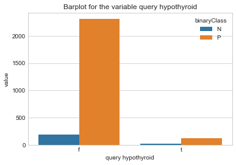

```
 Cross tab with count

binaryClass           N     P
query hyperthyroid
f                   202  2278
t                    14   149

 Cross tab with row %

col_0               binaryClass
query hyperthyroid
f                         100.0
t                         100.0
['query hyperthyroid', 'binaryClass', 'value']
```

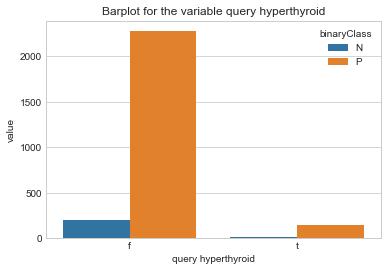

```
 Cross tab with count

binaryClass    N     P
lithium
f            215  2414
t              1    13

 Cross tab with row %

col_0    binaryClass
lithium
f              100.0
t              100.0
['lithium', 'binaryClass', 'value']
```

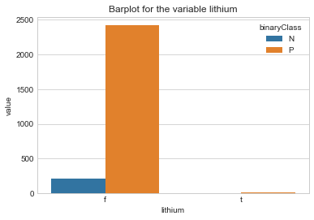

```
 Cross tab with count

binaryClass    N     P
goitre
f            216  2407
t              0    20

 Cross tab with row %

col_0   binaryClass
goitre
f             100.0
t             100.0
['goitre', 'binaryClass', 'value']
```

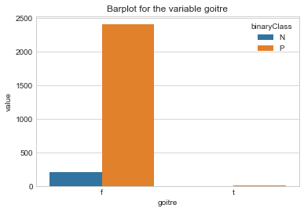

```
 Cross tab with count

binaryClass    N     P
tumor
f            211  2374
t              5    53

 Cross tab with row %

col_0  binaryClass
tumor
f            100.0
t            100.0
['tumor', 'binaryClass', 'value']
```

[3 more figures not shown]

```python
categorical_columns = ['sex', 'on thyroxine', 'query on thyroxine', 'on antithyroid medication', 'sick', \
                        'pregnant', 'thyroid surgery', 'I131 treatment', 'query hypothyroid', 'query hyperthyroid', \
                        'lithium', 'goitre', 'tumor', 'psych', 'referral source']
for name in categorical_columns:
    X1         = name
    target_Y   = 'binaryClass'
    xlab       = 'Sex'
    title      = "Barplot for the variable " + X1
    draw_barplot(df, X1, xlab, title, target_Y)
```